# An introduction to Python for Data Science

#### Is your head ready to explode yet?

- Another good online [Introduction](https://docs.python.org/2/tutorial/introduction.html)
- Other language features to learn as you wish
  - [Iterators](https://docs.python.org/2/whatsnew/2.2.html#pep-234-iterators)
  - [List Comprehensions](https://docs.python.org/2/whatsnew/2.0.html#list-comprehensions)
  - [Generators](https://docs.python.org/2/glossary.html#term-generator)
  - [Exceptions](https://docs.python.org/2/tutorial/errors.html)
  - [classes](https://docs.python.org/2/tutorial/classes.html)
  - [inheritance](https://docs.python.org/2/whatsnew/2.2.html#multiple-inheritance-the-diamond-rule)
  - [Abstract base classes](https://docs.python.org/2/whatsnew/2.6.html#pep-3119-abstract-base-classes)

## Exploring the Data Science Ecosystem

### The Data Science Eco System in Python

- array operations, statistics, linear algebra: [numpy](http://www.numpy.org/), [scipy](http://www.scipy.org)
- DataFrame: [pandas](http://pandas.pydata.org/)
- Machine Learning: [scikit-learn](http://scikit-learn.org/stable/)
- Plotting: [matplotlib](http://matplotlib.org/), also [Bokeh](http://bokeh.pydata.org/en/latest/), and [seaborn](http://stanford.edu/~mwaskom/software/seaborn/)
- Statistical models: [statsmodels](http://statsmodels.sourceforge.net/)
- Graphs/networks: [networkx](https://networkx.github.io/)
- Workbench: [ipython](http://ipython.org/)

### Plus the rest of the Python ecosystem

- [Django](https://www.djangoproject.com/)/[Flask](http://flask.pocoo.org/): Web sites
- [Jinja](http://jinja.pocoo.org/): Text formatting/templating
- [nose](https://nose.readthedocs.org/en/latest/): software testing
- [astroml](http://www.astroml.org/): All about Astronomy
  - Cool Binning Algorithm [Bayesian Blocks](http://www.astroml.org/examples/algorithms/plot_bayesian_blocks.html)
- [SQLAlchemy](http://www.sqlalchemy.org/): Database connections
- [Impyla](https://github.com/cloudera/impyla): Connecting to Hadoop/Impala

See more at the [PyPi(Python Package Index)](https://pypi.python.org/pypi)!

## iPython Notebook

- Interactive, Web Based Development Environment for Python
- Being Used for reproducible science
  - Being used for creating/writing academic papers
  - Everyone remember the funny video's Ernst played about Data Quality and Data Dictionaries!?
- Work is underway to expand the notebook for other programming languages
  - Julia
  - Haskell
  - bash
  - R
  - More!
- Some Great Example Notebooks
  - [Collection of notebook examples](https://github.com/ipython/ipython/wiki/A-gallery-of-interesting-IPython-Notebooks)
  - [Travelling Salesman Problem in Python](http://nbviewer.ipython.org/url/norvig.com/ipython/TSPv3.ipynb)

```python
# This hack will install a nifty plotting library
# that helps make pretty plots.

# From within the notebook, you can run shell commands on your computer!
!pip install seaborn astroML
```

```
You are using pip version 6.0.8, however version 7.0.1 is available.
```

```python
# If the above didn't work, try this ugly hack
import sys
for package in ["seaborn", "astroML"]:
    sys.argv = ["pip", "install", package]
    import pip
    pip.main()
```

```
You are using pip version 6.0.8, however version 7.0.1 is available.
You are using pip version 6.0.8, however version 7.0.1 is available.
```

```python
# Loading the python libraries we will need for today!

import pandas as pd  # Can now refere to pandas as "pd".  Convenience.
import sklearn
import matplotlib.pyplot as plt
import seaborn as sns
# Set up our session for interactive plotting.  (There's a config file knob somewhere I always forget to set)
%matplotlib inline
```

### Want to get help while using ipython ?

Type the name of the function, and then a question mark. Interactive help pops up!

### Want to see what methods an object supports ?

```python
# Read the documentaiton on read_csv
pd.read_csv?
```

```python
# Read the documentation on the dataframe
pd.DataFrame?
```

```python
# See what methods a dataframe supports, but placing your cursor on the right below, and presssing tab
pd.DataFrame.floordiv?
```

### Let's load some data!

We'll be using the [ILDP](https://archive.ics.uci.edu/ml/datasets/ILPD+%28Indian+Liver+Patient+Dataset%29) Dataset from homework 2

#### Dataset description

1. Age Age of the patient
2. Gender Gender of the patient
3. TB Total Bilirubin
4. DB Direct Bilirubin
5. Alkphos Alkaline Phosphotase
6. Sgpt Alamine Aminotransferase
7. Sgot Aspartate Aminotransferase
8. TP Total Protiens
9. ALB Albumin
10. A/G Ratio Albumin and Globulin Ratio
11. Selector field used to split the data into two sets (labeled by the experts)

```python
names = ["Age", "Gender", "TB", "DB", "Alkphos", "Sgpt", "Sgot", "TP", "ALB", "A/G", "Selector"]
```

```python
# Read Data into a DataFrame
# Support for reading a local file, website, etc
#frame = pd.read_csv("http://archive.ics.uci.edu/ml/machine-learning-databases/00225/Indian%20Liver%20Patient%20Dataset%20(ILPD).csv")
frame = pd.read_csv("http://archive.ics.uci.edu/ml/machine-learning-databases/00225/Indian%20Liver%20Patient%20Dataset%20(ILPD).csv", header=False, names=names)
```

```python
frame
```

|  | Age | Gender | TB | DB | Alkphos | Sgpt | Sgot | TP | ALB | A/G | Selector |
| --- | --- | --- | --- | --- | --- | --- | --- | --- | --- | --- | --- |
| 0 | 62 | Male | 10.9 | 5.5 | 699 | 64 | 100 | 7.5 | 3.2 | 0.74 | 1 |
| 1 | 62 | Male | 7.3 | 4.1 | 490 | 60 | 68 | 7.0 | 3.3 | 0.89 | 1 |
| 2 | 58 | Male | 1.0 | 0.4 | 182 | 14 | 20 | 6.8 | 3.4 | 1.00 | 1 |
| 3 | 72 | Male | 3.9 | 2.0 | 195 | 27 | 59 | 7.3 | 2.4 | 0.40 | 1 |
| 4 | 46 | Male | 1.8 | 0.7 | 208 | 19 | 14 | 7.6 | 4.4 | 1.30 | 1 |
| 5 | 26 | Female | 0.9 | 0.2 | 154 | 16 | 12 | 7.0 | 3.5 | 1.00 | 1 |
| 6 | 29 | Female | 0.9 | 0.3 | 202 | 14 | 11 | 6.7 | 3.6 | 1.10 | 1 |
| 7 | 17 | Male | 0.9 | 0.3 | 202 | 22 | 19 | 7.4 | 4.1 | 1.20 | 2 |
| 8 | 55 | Male | 0.7 | 0.2 | 290 | 53 | 58 | 6.8 | 3.4 | 1.00 | 1 |
| 9 | 57 | Male | 0.6 | 0.1 | 210 | 51 | 59 | 5.9 | 2.7 | 0.80 | 1 |
| 10 | 72 | Male | 2.7 | 1.3 | 260 | 31 | 56 | 7.4 | 3.0 | 0.60 | 1 |
| 11 | 64 | Male | 0.9 | 0.3 | 310 | 61 | 58 | 7.0 | 3.4 | 0.90 | 2 |
| 12 | 74 | Female | 1.1 | 0.4 | 214 | 22 | 30 | 8.1 | 4.1 | 1.00 | 1 |
| 13 | 61 | Male | 0.7 | 0.2 | 145 | 53 | 41 | 5.8 | 2.7 | 0.87 | 1 |
| 14 | 25 | Male | 0.6 | 0.1 | 183 | 91 | 53 | 5.5 | 2.3 | 0.70 | 2 |
| 15 | 38 | Male | 1.8 | 0.8 | 342 | 168 | 441 | 7.6 | 4.4 | 1.30 | 1 |
| 16 | 33 | Male | 1.6 | 0.5 | 165 | 15 | 23 | 7.3 | 3.5 | 0.92 | 2 |
| 17 | 40 | Female | 0.9 | 0.3 | 293 | 232 | 245 | 6.8 | 3.1 | 0.80 | 1 |
| 18 | 40 | Female | 0.9 | 0.3 | 293 | 232 | 245 | 6.8 | 3.1 | 0.80 | 1 |
| 19 | 51 | Male | 2.2 | 1.0 | 610 | 17 | 28 | 7.3 | 2.6 | 0.55 | 1 |
| 20 | 51 | Male | 2.9 | 1.3 | 482 | 22 | 34 | 7.0 | 2.4 | 0.50 | 1 |
| 21 | 62 | Male | 6.8 | 3.0 | 542 | 116 | 66 | 6.4 | 3.1 | 0.90 | 1 |
| 22 | 40 | Male | 1.9 | 1.0 | 231 | 16 | 55 | 4.3 | 1.6 | 0.60 | 1 |
| 23 | 63 | Male | 0.9 | 0.2 | 194 | 52 | 45 | 6.0 | 3.9 | 1.85 | 2 |
| 24 | 34 | Male | 4.1 | 2.0 | 289 | 875 | 731 | 5.0 | 2.7 | 1.10 | 1 |
| 25 | 34 | Male | 4.1 | 2.0 | 289 | 875 | 731 | 5.0 | 2.7 | 1.10 | 1 |
| 26 | 34 | Male | 6.2 | 3.0 | 240 | 1680 | 850 | 7.2 | 4.0 | 1.20 | 1 |
| 27 | 20 | Male | 1.1 | 0.5 | 128 | 20 | 30 | 3.9 | 1.9 | 0.95 | 2 |
| 28 | 84 | Female | 0.7 | 0.2 | 188 | 13 | 21 | 6.0 | 3.2 | 1.10 | 2 |
| 29 | 57 | Male | 4.0 | 1.9 | 190 | 45 | 111 | 5.2 | 1.5 | 0.40 | 1 |
| ... | ... | ... | ... | ... | ... | ... | ... | ... | ... | ... | ... |
| 552 | 46 | Male | 10.2 | 4.2 | 232 | 58 | 140 | 7.0 | 2.7 | 0.60 | 1 |
| 553 | 73 | Male | 1.8 | 0.9 | 220 | 20 | 43 | 6.5 | 3.0 | 0.80 | 1 |
| 554 | 55 | Male | 0.8 | 0.2 | 290 | 139 | 87 | 7.0 | 3.0 | 0.70 | 1 |
| 555 | 51 | Male | 0.7 | 0.1 | 180 | 25 | 27 | 6.1 | 3.1 | 1.00 | 1 |
| 556 | 51 | Male | 2.9 | 1.2 | 189 | 80 | 125 | 6.2 | 3.1 | 1.00 | 1 |
| 557 | 51 | Male | 4.0 | 2.5 | 275 | 382 | 330 | 7.5 | 4.0 | 1.10 | 1 |
| 558 | 26 | Male | 42.8 | 19.7 | 390 | 75 | 138 | 7.5 | 2.6 | 0.50 | 1 |
| 559 | 66 | Male | 15.2 | 7.7 | 356 | 321 | 562 | 6.5 | 2.2 | 0.40 | 1 |
| 560 | 66 | Male | 16.6 | 7.6 | 315 | 233 | 384 | 6.9 | 2.0 | 0.40 | 1 |
| 561 | 66 | Male | 17.3 | 8.5 | 388 | 173 | 367 | 7.8 | 2.6 | 0.50 | 1 |
| 562 | 64 | Male | 1.4 | 0.5 | 298 | 31 | 83 | 7.2 | 2.6 | 0.50 | 1 |
| 563 | 38 | Female | 0.6 | 0.1 | 165 | 22 | 34 | 5.9 | 2.9 | 0.90 | 2 |
| 564 | 43 | Male | 22.5 | 11.8 | 143 | 22 | 143 | 6.6 | 2.1 | 0.46 | 1 |
| 565 | 50 | Female | 1.0 | 0.3 | 191 | 22 | 31 | 7.8 | 4.0 | 1.00 | 2 |
| 566 | 52 | Male | 2.7 | 1.4 | 251 | 20 | 40 | 6.0 | 1.7 | 0.39 | 1 |
| 567 | 20 | Female | 16.7 | 8.4 | 200 | 91 | 101 | 6.9 | 3.5 | 1.02 | 1 |
| 568 | 16 | Male | 7.7 | 4.1 | 268 | 213 | 168 | 7.1 | 4.0 | 1.20 | 1 |
| 569 | 16 | Male | 2.6 | 1.2 | 236 | 131 | 90 | 5.4 | 2.6 | 0.90 | 1 |
| 570 | 90 | Male | 1.1 | 0.3 | 215 | 46 | 134 | 6.9 | 3.0 | 0.70 | 1 |
| 571 | 32 | Male | 15.6 | 9.5 | 134 | 54 | 125 | 5.6 | 4.0 | 2.50 | 1 |
| 572 | 32 | Male | 3.7 | 1.6 | 612 | 50 | 88 | 6.2 | 1.9 | 0.40 | 1 |
| 573 | 32 | Male | 12.1 | 6.0 | 515 | 48 | 92 | 6.6 | 2.4 | 0.50 | 1 |
| 574 | 32 | Male | 25.0 | 13.7 | 560 | 41 | 88 | 7.9 | 2.5 | 2.50 | 1 |
| 575 | 32 | Male | 15.0 | 8.2 | 289 | 58 | 80 | 5.3 | 2.2 | 0.70 | 1 |
| 576 | 32 | Male | 12.7 | 8.4 | 190 | 28 | 47 | 5.4 | 2.6 | 0.90 | 1 |
| 577 | 60 | Male | 0.5 | 0.1 | 500 | 20 | 34 | 5.9 | 1.6 | 0.37 | 2 |
| 578 | 40 | Male | 0.6 | 0.1 | 98 | 35 | 31 | 6.0 | 3.2 | 1.10 | 1 |
| 579 | 52 | Male | 0.8 | 0.2 | 245 | 48 | 49 | 6.4 | 3.2 | 1.00 | 1 |
| 580 | 31 | Male | 1.3 | 0.5 | 184 | 29 | 32 | 6.8 | 3.4 | 1.00 | 1 |
| 581 | 38 | Male | 1.0 | 0.3 | 216 | 21 | 24 | 7.3 | 4.4 | 1.50 | 2 |

582 rows × 11 columns

```python
#TODO: What other pandas read methods are there?
# pd.read<TAB>
# How do they work ?
pd.read_clipboard?
```

```python
# Shape of the dataset, (Row, Columns)
frame.shape
```

```
(582, 11)
```

```python
# Deterine the types of variables... object == str.
frame.dtypes
```

```
Age           int64
Gender       object
TB          float64
DB          float64
Alkphos       int64
Sgpt          int64
Sgot          int64
TP          float64
ALB         float64
A/G         float64
Selector      int64
dtype: object
```

```python
frame.tail(10)
```

|  | Age | Gender | TB | DB | Alkphos | Sgpt | Sgot | TP | ALB | A/G | Selector |
| --- | --- | --- | --- | --- | --- | --- | --- | --- | --- | --- | --- |
| 572 | 32 | Male | 3.7 | 1.6 | 612 | 50 | 88 | 6.2 | 1.9 | 0.40 | 1 |
| 573 | 32 | Male | 12.1 | 6.0 | 515 | 48 | 92 | 6.6 | 2.4 | 0.50 | 1 |
| 574 | 32 | Male | 25.0 | 13.7 | 560 | 41 | 88 | 7.9 | 2.5 | 2.50 | 1 |
| 575 | 32 | Male | 15.0 | 8.2 | 289 | 58 | 80 | 5.3 | 2.2 | 0.70 | 1 |
| 576 | 32 | Male | 12.7 | 8.4 | 190 | 28 | 47 | 5.4 | 2.6 | 0.90 | 1 |
| 577 | 60 | Male | 0.5 | 0.1 | 500 | 20 | 34 | 5.9 | 1.6 | 0.37 | 2 |
| 578 | 40 | Male | 0.6 | 0.1 | 98 | 35 | 31 | 6.0 | 3.2 | 1.10 | 1 |
| 579 | 52 | Male | 0.8 | 0.2 | 245 | 48 | 49 | 6.4 | 3.2 | 1.00 | 1 |
| 580 | 31 | Male | 1.3 | 0.5 | 184 | 29 | 32 | 6.8 | 3.4 | 1.00 | 1 |
| 581 | 38 | Male | 1.0 | 0.3 | 216 | 21 | 24 | 7.3 | 4.4 | 1.50 | 2 |

```python
frame.describe?
```

```python
# Summary Statistics of numerical variables...
frame.describe()
```

|  | Age | TB | DB | Alkphos | Sgpt | Sgot | TP | ALB | A/G | Selector |
| --- | --- | --- | --- | --- | --- | --- | --- | --- | --- | --- |
| count | 582.000000 | 582.000000 | 582.000000 | 582.000000 | 582.000000 | 582.000000 | 582.000000 | 582.000000 | 578.000000 | 582.000000 |
| mean | 44.711340 | 3.303265 | 1.488488 | 290.754296 | 80.824742 | 110.068729 | 6.482646 | 3.141581 | 0.947145 | 1.286942 |
| std | 16.181921 | 6.213926 | 2.810324 | 243.108929 | 182.757696 | 289.141876 | 1.086306 | 0.796176 | 0.319863 | 0.452723 |
| min | 4.000000 | 0.400000 | 0.100000 | 63.000000 | 10.000000 | 10.000000 | 2.700000 | 0.900000 | 0.300000 | 1.000000 |
| 25% | 33.000000 | 0.800000 | 0.200000 | 175.250000 | 23.000000 | 25.000000 | 5.800000 | 2.600000 | 0.700000 | 1.000000 |
| 50% | 45.000000 | 1.000000 | 0.300000 | 208.000000 | 35.000000 | 42.000000 | 6.600000 | 3.100000 | 0.940000 | 1.000000 |
| 75% | 57.750000 | 2.600000 | 1.300000 | 298.000000 | 60.750000 | 87.000000 | 7.200000 | 3.800000 | 1.100000 | 2.000000 |
| max | 90.000000 | 75.000000 | 19.700000 | 2110.000000 | 2000.000000 | 4929.000000 | 9.600000 | 5.500000 | 2.800000 | 2.000000 |

```python
## Accessing only one column:
print frame["Age"].describe()

# or accessing two columns
print frame[["Age", "TP" ]].head(15)
```

```
count    582.000000
mean      44.711340
std       16.181921
min        4.000000
25%       33.000000
50%       45.000000
75%       57.750000
max       90.000000
Name: Age, dtype: float64
    Age   TP
0    62  7.5
1    62  7.0
2    58  6.8
3    72  7.3
4    46  7.6
5    26  7.0
6    29  6.7
7    17  7.4
8    55  6.8
9    57  5.9
10   72  7.4
11   64  7.0
12   74  8.1
13   61  5.8
14   25  5.5
```

```python
# Gender - it is an object, so let's count occurences of each unique value
frame["Gender"].value_counts()
```

```
Male      441
Female    141
dtype: int64
```

```python
type(frame["Gender"].value_counts())
```

```
pandas.core.series.Series
```

## Data Cleansing

If you remember from homework 2, we dealt with some data cleansing tasks. Dropping Nulls is easy

```python
frame.isnull().sum()
```

```
Age         0
Gender      0
TB          0
DB          0
Alkphos     0
Sgpt        0
Sgot        0
TP          0
ALB         0
A/G         4
Selector    0
dtype: int64
```

```python
frame.dropna().describe()
```

|  | Age | TB | DB | Alkphos | Sgpt | Sgot | TP | ALB | A/G | Selector |
| --- | --- | --- | --- | --- | --- | --- | --- | --- | --- | --- |
| count | 578.000000 | 578.000000 | 578.00000 | 578.000000 | 578.000000 | 578.000000 | 578.000000 | 578.000000 | 578.000000 | 578.000000 |
| mean | 44.747405 | 3.319896 | 1.49654 | 291.546713 | 81.238754 | 110.574394 | 6.481142 | 3.138235 | 0.947145 | 1.285467 |
| std | 16.213968 | 6.232158 | 2.81834 | 243.734041 | 183.321431 | 290.075539 | 1.085500 | 0.795094 | 0.319863 | 0.452028 |
| min | 4.000000 | 0.400000 | 0.10000 | 63.000000 | 10.000000 | 10.000000 | 2.700000 | 0.900000 | 0.300000 | 1.000000 |
| 25% | 33.000000 | 0.800000 | 0.20000 | 175.250000 | 23.250000 | 25.000000 | 5.800000 | 2.600000 | 0.700000 | 1.000000 |
| 50% | 45.000000 | 1.000000 | 0.30000 | 208.500000 | 35.000000 | 42.000000 | 6.600000 | 3.100000 | 0.940000 | 1.000000 |
| 75% | 58.000000 | 2.600000 | 1.30000 | 298.000000 | 61.000000 | 87.000000 | 7.200000 | 3.800000 | 1.100000 | 2.000000 |
| max | 90.000000 | 75.000000 | 19.70000 | 2110.000000 | 2000.000000 | 4929.000000 | 9.600000 | 5.500000 | 2.800000 | 2.000000 |

```python
# To modify the dataframe in place, add inplace=True
frame.dropna(inplace=True)
```

## Visualizing the Data

```python
frame["Gender"].value_counts()
```

```
Male      439
Female    139
dtype: int64
```

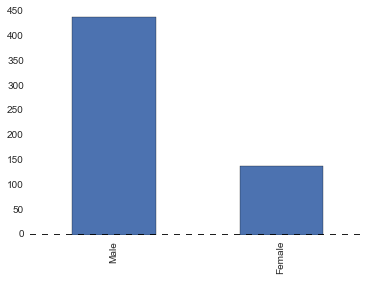

```python
# Histogram of Gender
frame["Gender"].value_counts().plot(kind="bar")
```

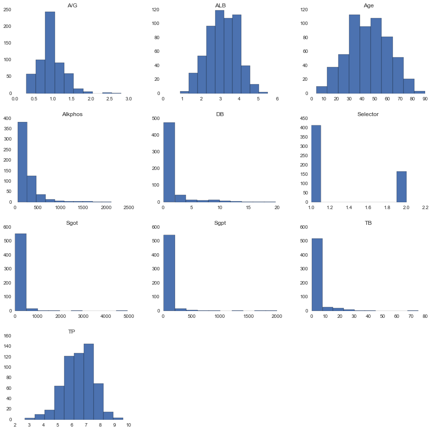

```python
# Histograms of all of the variables!
# frame.hist() returns an array of all of the plots.  We use the "_" to ignore the return value
_ = frame.hist( figsize=(15,15))
```

[output not shown]

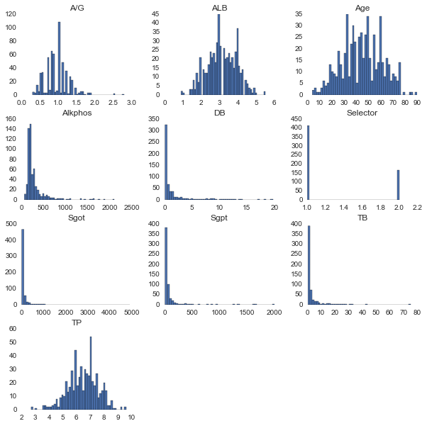

```python
# TODO: Better bin sizes for all plots?
frame.hist(bins=50, figsize=(10,10))
```

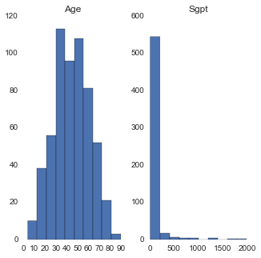

```python
# TODO:  Plot a histogram of Two Columns
# TODO:  Experiment with different bins, what looks good ?
_ = frame[["Age", "Sgpt"]].hist(figsize=(5,5))
```

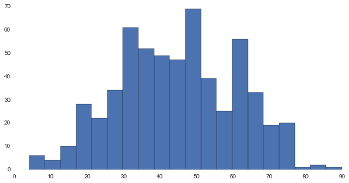

```python
# Let's look at Ages again.  The variable is an integer...
frame["Age"].hist(bins=20, figsize=(10,5))
```

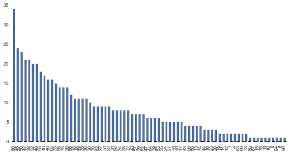

```python
# Another way to plot a histogram, which works for integers
ages = frame["Age"].value_counts()
ages.plot(kind="bar", figsize=(10,5))
```

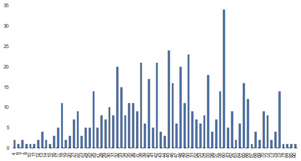

```python
# This is a bit better histogram,
ages = frame["Age"].value_counts().sort_index()
ages.plot(kind="bar", figsize=(10,5))
```

### One Last Fun Bin Technique for Histograms: Bayesian Blocks Binning

Use a dynamic algorithm to determine the bins that best describe the data set. The bins do not have uniform width, but instead adapt to the distribution of the data.

- [Astronomical Paper](http://adsabs.harvard.edu/abs/2012arXiv1207.5578S)
- [Easier Introduction to the above](http://www.astroml.org/examples/algorithms/plot_bayesian_blocks.html)

```python
from astroML.plotting import hist
```

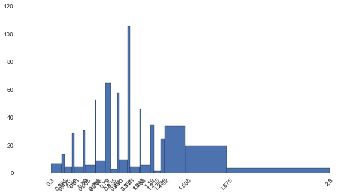

```python
f, ax = plt.subplots(figsize=(10, 5))
counts, edges, plot_objects = hist(frame["A/G"], bins="blocks", ax=ax)
_ = ax.set_xticks(edges)
_ = ax.set_xticklabels(edges, rotation=45)
```

```python
print edges
```

[output not shown]

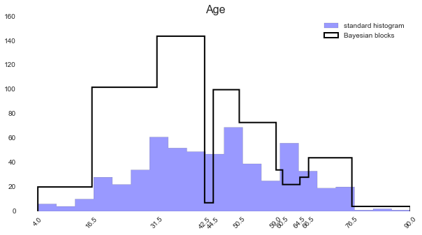

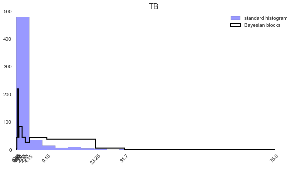

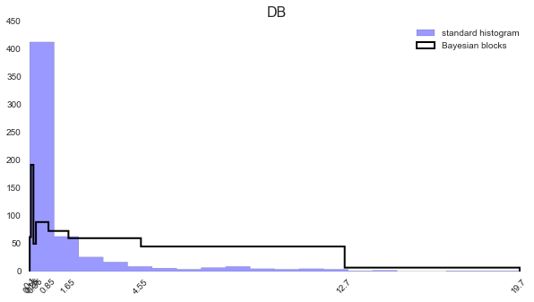

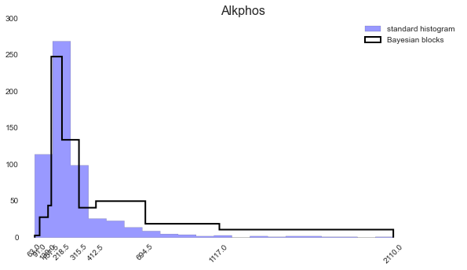

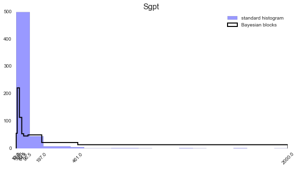

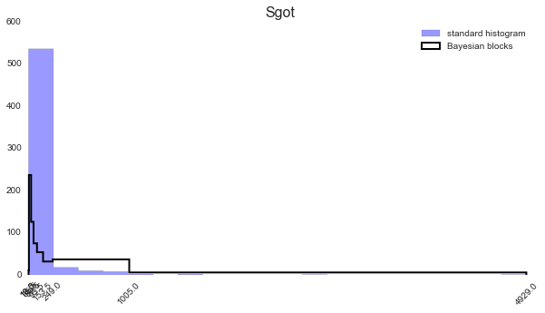

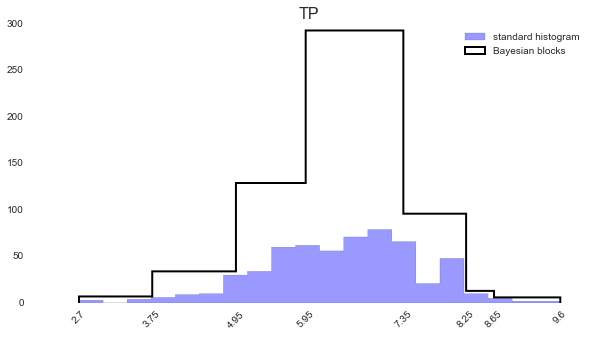

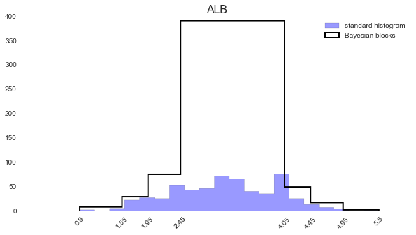

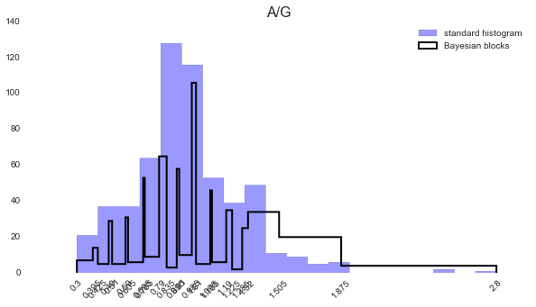

```python
for column in frame.columns:
    if column == "Gender" or column == "Selector":
        continue
    f, ax = plt.subplots(figsize=(10, 5))
    # Plot a regular histogram
    hist(frame[column], bins=20, histtype='stepfilled', ax=ax,  alpha=0.4,  color="blue", label='standard histogram')
    # Overlay the Bayesian Blocks outline
    counts, edges, plot_objects = hist(frame[column], bins="blocks",  color="black", ax=ax, linewidth=2, histtype='step', label="Bayesian blocks")
    # Toss on a legend, title, and have reasonable xlabels.
    ax.legend()
    ax.set_title(column, size=16)
    _ = ax.set_xticks(edges)
    _ = ax.set_xticklabels(edges, rotation=45)
```

### Outlier Removal

SGOT: Remove Everything greater than 2 standard deviations away from the mean

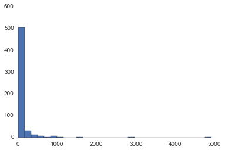

```python
frame["Sgot"].hist(bins=30)
```

```python
sgot = frame["Sgot"].describe()
print sgot
```

```
count     578.000000
mean      110.574394
std       290.075539
min        10.000000
25%        25.000000
50%        42.000000
75%        87.000000
max      4929.000000
Name: Sgot, dtype: float64
```

```python
#
high_limit = sgot["mean"] + 2 * sgot["std"]

print "Sgot high limit is ", high_limit
boolean_series = frame["Sgot"] < high_limit
print boolean_series
```

```
Sgot high limit is  690.725473222
0     True
1     True
2     True
3     True
4     True
5     True
6     True
7     True
8     True
9     True
10    True
11    True
12    True
13    True
```

[output cut: 18 more lines]

```python
frame = frame[boolean_series]
frame["Sgot"].describe()
```

```
count    562.000000
mean      75.492883
std       97.202643
min       10.000000
25%       25.000000
50%       41.000000
75%       80.750000
max      630.000000
Name: Sgot, dtype: float64
```

## Data Exploration, Visualization

### Scatter plots of all pairwise relationships

```python
frame.describe()
```

|  | Age | TB | DB | Alkphos | Sgpt | Sgot | TP | ALB | A/G | Selector |
| --- | --- | --- | --- | --- | --- | --- | --- | --- | --- | --- |
| count | 562.000000 | 562.000000 | 562.000000 | 562.000000 | 562.000000 | 562.000000 | 562.000000 | 562.000000 | 562.000000 | 562.000000 |
| mean | 44.916370 | 3.170641 | 1.427046 | 288.928826 | 56.350534 | 75.492883 | 6.494128 | 3.147331 | 0.948879 | 1.293594 |
| std | 16.205733 | 6.151310 | 2.782005 | 239.880954 | 68.042138 | 97.202643 | 1.083609 | 0.797859 | 0.320405 | 0.455814 |
| min | 4.000000 | 0.400000 | 0.100000 | 63.000000 | 10.000000 | 10.000000 | 2.700000 | 0.900000 | 0.300000 | 1.000000 |
| 25% | 33.000000 | 0.800000 | 0.200000 | 175.000000 | 23.000000 | 25.000000 | 5.800000 | 2.600000 | 0.700000 | 1.000000 |
| 50% | 45.000000 | 1.000000 | 0.300000 | 206.000000 | 34.500000 | 41.000000 | 6.600000 | 3.100000 | 0.950000 | 1.000000 |
| 75% | 58.000000 | 2.400000 | 1.200000 | 298.000000 | 58.000000 | 80.750000 | 7.200000 | 3.800000 | 1.100000 | 2.000000 |
| max | 90.000000 | 75.000000 | 19.700000 | 2110.000000 | 622.000000 | 630.000000 | 9.600000 | 5.500000 | 2.800000 | 2.000000 |

```python
sns.pairplot?
```

```python
sns.pairplot(frame, hue="Selector", size=2.5)

# Could also plot with hue="Gender", or hue="Age", or any discrete features
```

[figure not shown]

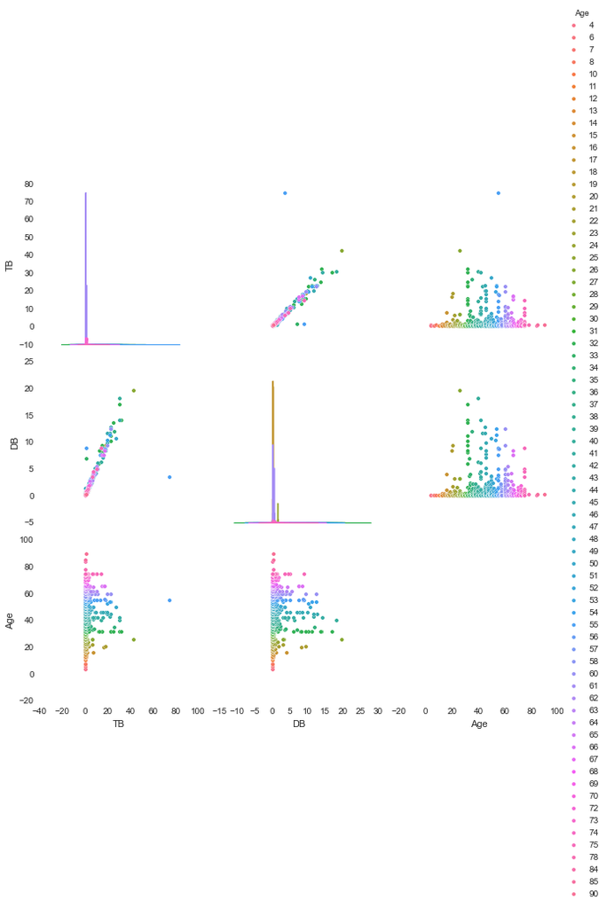

```python
# TODO: What variables look the most interesting?  Can you produce a pairwise plot with just those columns?
sns.pairplot(frame[["TB", "DB", "Age"]], hue="Age", diag_kind="kde")
```

## Back To DataFrames

### Selecting Rows:

```python
dudes = frame[frame["Gender"] == "Male"]
```

```python
## Selecting Age Ranges
whipper_snappers = frame[(frame["Age"] < 30) & (frame["Age"] > 20)]
whipper_snappers.head()
```

|  | Age | Gender | TB | DB | Alkphos | Sgpt | Sgot | TP | ALB | A/G | Selector |
| --- | --- | --- | --- | --- | --- | --- | --- | --- | --- | --- | --- |
| 5 | 26 | Female | 0.9 | 0.2 | 154 | 16 | 12 | 7.0 | 3.5 | 1.00 | 1 |
| 6 | 29 | Female | 0.9 | 0.3 | 202 | 14 | 11 | 6.7 | 3.6 | 1.10 | 1 |
| 14 | 25 | Male | 0.6 | 0.1 | 183 | 91 | 53 | 5.5 | 2.3 | 0.70 | 2 |
| 45 | 21 | Male | 3.9 | 1.8 | 150 | 36 | 27 | 6.8 | 3.9 | 1.34 | 1 |
| 74 | 29 | Female | 0.7 | 0.1 | 162 | 52 | 41 | 5.2 | 2.5 | 0.90 | 2 |

```python
whipper_snappers.describe()
```

|  | Age | TB | DB | Alkphos | Sgpt | Sgot | TP | ALB | A/G | Selector |
| --- | --- | --- | --- | --- | --- | --- | --- | --- | --- | --- |
| count | 63.000000 | 63.000000 | 63.000000 | 63.000000 | 63.000000 | 63.000000 | 63.000000 | 63.000000 | 63.000000 | 63.000000 |
| mean | 25.158730 | 2.315873 | 0.953968 | 204.190476 | 49.349206 | 58.809524 | 6.652381 | 3.423810 | 1.058730 | 1.460317 |
| std | 2.622522 | 5.786252 | 2.745191 | 109.881587 | 57.104364 | 82.853126 | 1.231686 | 0.868761 | 0.301649 | 0.502426 |
| min | 21.000000 | 0.600000 | 0.100000 | 75.000000 | 11.000000 | 10.000000 | 2.800000 | 0.900000 | 0.300000 | 1.000000 |
| 25% | 22.500000 | 0.700000 | 0.200000 | 156.500000 | 21.500000 | 22.500000 | 6.100000 | 2.900000 | 0.900000 | 1.000000 |
| 50% | 26.000000 | 0.900000 | 0.200000 | 180.000000 | 33.000000 | 31.000000 | 6.800000 | 3.600000 | 1.000000 | 1.000000 |
| 75% | 27.000000 | 1.250000 | 0.450000 | 207.500000 | 54.500000 | 56.500000 | 7.600000 | 4.050000 | 1.200000 | 2.000000 |
| max | 29.000000 | 42.800000 | 19.700000 | 850.000000 | 390.000000 | 500.000000 | 8.500000 | 5.500000 | 1.850000 | 2.000000 |

```python
#TODO:
# How to select all Females > 50 ?
frame[(frame["Age"] > 50) & (frame["Gender"] == "Female")].describe()
```

|  | Age | TB | DB | Alkphos | Sgpt | Sgot | TP | ALB | A/G | Selector |
| --- | --- | --- | --- | --- | --- | --- | --- | --- | --- | --- |
| count | 38.000000 | 38.000000 | 38.000000 | 38.000000 | 38.000000 | 38.000000 | 38.000000 | 38.000000 | 38.000000 | 38.000000 |
| mean | 62.447368 | 2.836842 | 1.302632 | 394.894737 | 32.631579 | 39.973684 | 6.468421 | 3.081579 | 0.890526 | 1.368421 |
| std | 8.997589 | 5.257295 | 2.787665 | 440.855176 | 21.237933 | 30.802323 | 1.128047 | 0.803323 | 0.265472 | 0.488852 |
| min | 51.000000 | 0.600000 | 0.100000 | 130.000000 | 10.000000 | 12.000000 | 4.400000 | 1.600000 | 0.400000 | 1.000000 |
| 25% | 55.000000 | 0.700000 | 0.200000 | 179.000000 | 18.500000 | 20.250000 | 5.850000 | 2.500000 | 0.712500 | 1.000000 |
| 50% | 59.000000 | 0.850000 | 0.200000 | 203.500000 | 24.000000 | 29.500000 | 6.700000 | 3.200000 | 0.900000 | 1.000000 |
| 75% | 68.000000 | 1.625000 | 0.775000 | 332.500000 | 42.750000 | 46.500000 | 7.075000 | 3.675000 | 1.000000 | 2.000000 |
| max | 85.000000 | 23.200000 | 12.600000 | 1896.000000 | 96.000000 | 142.000000 | 8.400000 | 4.900000 | 1.400000 | 2.000000 |

### Randomly selecting rows

To create a training set, and a test set ?

```python
import numpy.random
```

```python
numpy.random.choice?
```

```python
num_rows = frame.shape[0]
training_indices = numpy.random.choice(frame.index, num_rows * .6, replace=False)
test_indices = set(frame.index) - set(training_indices)
```

```python
print "Training set is ", len(training_indices), "items, and is type", type(training_indices)
print "Test set is     ", len(test_indices), "items, and is type", type(test_indices)
```

```
Training set is  337 items, and is type <type 'numpy.ndarray'>
Test set is      225 items, and is type <type 'set'>
```

```python
training = frame.ix[training_indices]
training.head()
```

|  | Age | Gender | TB | DB | Alkphos | Sgpt | Sgot | TP | ALB | A/G | Selector |
| --- | --- | --- | --- | --- | --- | --- | --- | --- | --- | --- | --- |
| 418 | 55 | Female | 8.2 | 3.9 | 1350 | 52 | 65 | 6.7 | 2.9 | 0.70 | 1 |
| 238 | 40 | Male | 0.9 | 0.3 | 196 | 69 | 48 | 6.8 | 3.1 | 0.80 | 1 |
| 469 | 66 | Male | 1.1 | 0.5 | 167 | 13 | 56 | 7.1 | 4.1 | 1.36 | 1 |
| 451 | 58 | Male | 0.9 | 0.2 | 1100 | 25 | 36 | 7.1 | 3.5 | 0.90 | 1 |
| 214 | 66 | Male | 0.6 | 0.2 | 100 | 17 | 148 | 5.0 | 3.3 | 1.90 | 2 |

```python
testing = frame.ix[test_indices]
testing.head()
```

|  | Age | Gender | TB | DB | Alkphos | Sgpt | Sgot | TP | ALB | A/G | Selector |
| --- | --- | --- | --- | --- | --- | --- | --- | --- | --- | --- | --- |
| 512 | 69 | Male | 0.9 | 0.2 | 215 | 32 | 24 | 6.9 | 3.0 | 0.70 | 1 |
| 1 | 62 | Male | 7.3 | 4.1 | 490 | 60 | 68 | 7.0 | 3.3 | 0.89 | 1 |
| 2 | 58 | Male | 1.0 | 0.4 | 182 | 14 | 20 | 6.8 | 3.4 | 1.00 | 1 |
| 3 | 72 | Male | 3.9 | 2.0 | 195 | 27 | 59 | 7.3 | 2.4 | 0.40 | 1 |
| 516 | 28 | Male | 0.9 | 0.2 | 215 | 50 | 28 | 8.0 | 4.0 | 1.00 | 1 |

**Q: This is Python, there is a library that does this somewhere - shouldn't I be using that ?!**

*A: YES! (but you should also know how it works)*

```python
from sklearn.cross_validation import train_test_split
```

```python
train_test_split??
```

```python
training_data, testing_data = train_test_split(frame, test_size=.4)
```

```python
training_data.shape
```

```
(337L, 11L)
```

```python
testing_data.shape
```

```
(225L, 11L)
```

## Double Bonus, more plotting

### Correlation between variables

```python
sns.corrplot??
```

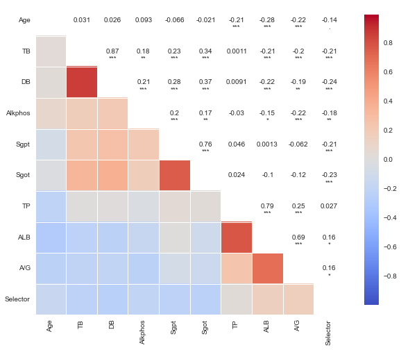

```python
f, ax = plt.subplots(figsize=(10, 10))
_ = sns.corrplot(frame, annot=True,  diag_names=False, ax=ax)
```

#### TODO: What does the above correlation graph tell you ?

### Closer look at a single pair of variables

```python
sns.jointplot?
```

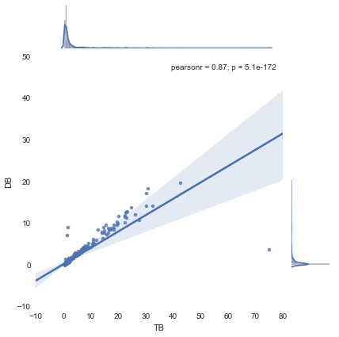

```python
sns.jointplot(frame["TB"], frame["DB"], kind="reg")
```

### Mulitple Linear Regressions.

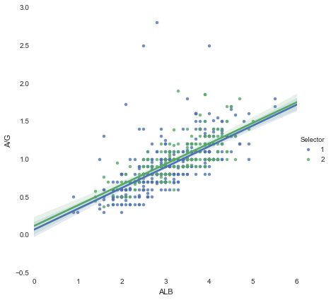

```python
g = sns.lmplot("ALB", "A/G", hue="Selector", data=frame,
                size=6)
```

### Want More ? Look Here!

- [Python.org](http://www.python.org) Language Homepage. Where else?
- pydata.org One home of a large group of data scientists
  - [Seattle PyData Conference](http://seattle.pydata.org/) Coming this summer! July 24th - 26th)
  - [David Beazley's Homepage](http://www.dabeaz.com/) The best teacher I've found for beginning to advanced python.
    - Book Recommendation Python Essential Reference (4th Edition) (aka The Castle Book)
- [Python Parambulations](https://jakevdp.github.io/) Lengthly posts describing using Python for Science.